# Saemix fits with different error models

Emmanuelle

30/04/2020

## Saemix fits with different error models

### Objective

Investigate why sometimes saemix doesn’t converge and leads to outlandish estimates including variabilities of several thousands.

### Simulation using the same setting as Dubois et al. 2011

```r
# Parameters
psi1<-c(1.5, 5, 0.04)
omega1<-diag(c(0.05, 0.0125, 0.05))
res1<-c(0.1,0.1)

# Model
model1cpt<-function(psi,id,xidep) {
  tim<-xidep[,1]
  dose<-xidep[,2]
  ka<-psi[id,1]
  V<-psi[id,2]
  CL<-psi[id,3]
  k<-CL/V
  ypred<-dose*ka/(V*(ka-k))*(exp(-k*tim)-exp(-ka*tim))
  return(ypred)
}

# Settings
N <- 50
tim <- c(0,0.25,0.5,1,2,3.5,5,7,9,12,24)
dose<-4

simdat<-data.frame(id=rep(1:N,each=length(tim)),time=rep(tim,N),dose=dose)

psipar<-do.call(rbind,rep(list(psi1),N))
for(i in 1:3) psipar[,i]<-psipar[,i]*exp(rnorm(N,mean=0,sd=sqrt(omega1[i,i])))
summary(psipar)
```

```
##        V1               V2              V3
##  Min.   :0.8155   Min.   :3.941   Min.   :0.01772
##  1st Qu.:1.2692   1st Qu.:4.718   1st Qu.:0.03172
##  Median :1.4783   Median :5.080   Median :0.03907
##  Mean   :1.4880   Mean   :5.162   Mean   :0.03927
##  3rd Qu.:1.6455   3rd Qu.:5.617   3rd Qu.:0.04415
##  Max.   :2.6947   Max.   :6.644   Max.   :0.06782
```

```r
apply(psipar,2,sd)
```

```
## [1] 0.34673071 0.59658145 0.01002139
```

```r
ypred<-model1cpt(psipar,id=1:N,xidep=simdat[,2:3])
gpred<-error(ypred,res1,etype=rep(1,length(ypred)))
simdat$conc<-ypred+rnorm(length(ypred),mean=0,sd=gpred)

# Saemix data
saemix.data<-saemixData(name.data=simdat,header=TRUE,sep="",na=NA, name.group=c("id"), name.predictors=c("time","dose"),name.response=c("conc"))
```

```
## Using the object called simdat in this R session as the data.
##
##
## The following SaemixData object was successfully created:
##
## Object of class SaemixData
##     longitudinal data for use with the SAEM algorithm
## Dataset simdat
##     Structured data: conc ~ time + dose | id
##     X variable for graphs: time ()
```

```r
simdat2<-simdat
simdat2$conc[simdat2$time==0]<-0
saemix.data2<-saemixData(name.data=simdat2,header=TRUE,sep="",na=NA, name.group=c("id"), name.predictors=c("time","dose"),name.response=c("conc"))
```

```
## Using the object called simdat2 in this R session as the data.
##
##
## The following SaemixData object was successfully created:
##
## Object of class SaemixData
##     longitudinal data for use with the SAEM algorithm
## Dataset simdat2
##     Structured data: conc ~ time + dose | id
##     X variable for graphs: time ()
```

```r
simdat3<-simdat2[simdat2$time>0,]
saemix.data3<-saemixData(name.data=simdat3,header=TRUE,sep="",na=NA, name.group=c("id"), name.predictors=c("time","dose"),name.response=c("conc"))
```

```
## Using the object called simdat3 in this R session as the data.
##
##
## The following SaemixData object was successfully created:
##
## Object of class SaemixData
##     longitudinal data for use with the SAEM algorithm
## Dataset simdat3
##     Structured data: conc ~ time + dose | id
##     X variable for graphs: time ()
```

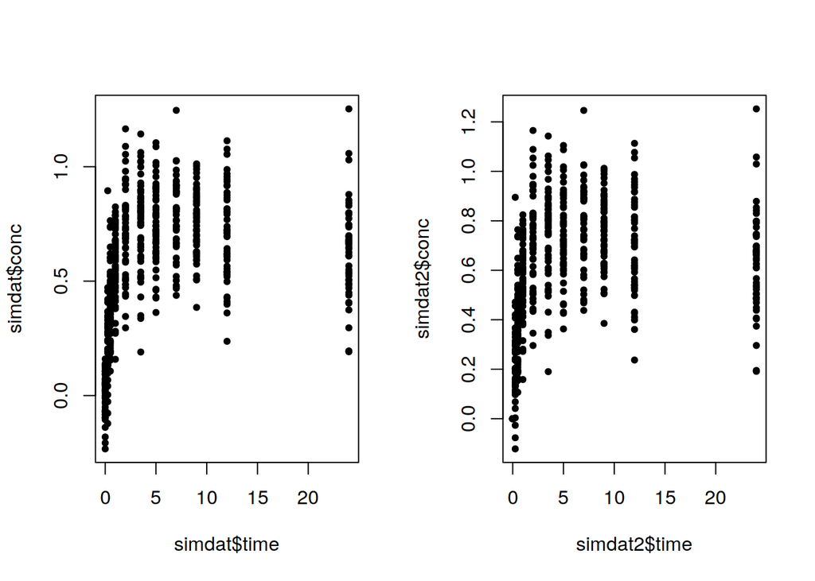

```r
par(mfrow=c(1,2))
plot(simdat$time,simdat$conc,pch=20)
plot(simdat2$time,simdat2$conc,pch=20)
```

```r
if(FALSE) {
  namfile<-file.path(melDir,"simulationsTlag.csv")
  simdat.mlx<-simdat
  simdat.mlx$dose[simdat.mlx$time>0]<-NA
  write.table(simdat.mlx,namfile, row.names=FALSE, quote=FALSE,na=".")
}
```

Showing results:

```r
print(fit1@results)
```

```
## ----------------------------------------------------
## -----------------  Fixed effects  ------------------
## ----------------------------------------------------
##      Parameter Estimate SE     CV(%)
## [1,] ka        1.331    0.0961  7.2
## [2,] V         5.028    0.1120  2.2
## [3,] CL        0.044    0.0096 21.8
## [4,] a.1       0.164    0.0055  3.4
## ----------------------------------------------------
## -----------  Variance of random effects  -----------
## ----------------------------------------------------
##    Parameter Estimate SE     CV(%)
## ka omega2.ka 0.0495   0.0391  79
## V  omega2.V  0.0036   0.0025  70
## CL omega2.CL 0.1760   0.2771 157
## ----------------------------------------------------
## ------  Correlation matrix of random effects  ------
## ----------------------------------------------------
##           omega2.ka omega2.V omega2.CL
## omega2.ka 1         0        0
## omega2.V  0         1        0
## omega2.CL 0         0        1
## ----------------------------------------------------
## ---------------  Statistical criteria  -------------
## ----------------------------------------------------
## Likelihood computed by linearisation
##       -2LL= -387.6674
##       AIC = -373.6674
##       BIC = -360.2832
##
## Likelihood computed by importance sampling
##       -2LL= -387.3352
##       AIC = -373.3352
##       BIC = -359.9511
## ----------------------------------------------------
```

```r
print(fit2@results)
```

```
## ----------------------------------------------------
## -----------------  Fixed effects  ------------------
## ----------------------------------------------------
##      Parameter Estimate SE  CV(%)
## [1,] ka        1.49     NaN NaN
## [2,] V         5.19     NaN NaN
## [3,] CL        0.04     NaN NaN
## [4,] b.1       0.73     NaN NaN
## ----------------------------------------------------
## -----------  Variance of random effects  -----------
## ----------------------------------------------------
##    Parameter Estimate SE  CV(%)
## ka omega2.ka 0.25     NaN NaN
## V  omega2.V  0.24     NaN NaN
## CL omega2.CL 0.27     NaN NaN
## ----------------------------------------------------
## ------  Correlation matrix of random effects  ------
## ----------------------------------------------------
##           omega2.ka omega2.V omega2.CL
## omega2.ka 1         0        0
## omega2.V  0         1        0
## omega2.CL 0         0        1
## ----------------------------------------------------
## ---------------  Statistical criteria  -------------
## ----------------------------------------------------
## Likelihood computed by linearisation
##       -2LL= NaN
##       AIC = NaN
##       BIC = NaN
##
## Likelihood computed by importance sampling
##       -2LL= 70839.64
##       AIC = 70853.64
##       BIC = 70867.03
## ----------------------------------------------------
```

```r
print(fit2b@results)
```

```
## ----------------------------------------------------
## -----------------  Fixed effects  ------------------
## ----------------------------------------------------
##      Parameter Estimate SE  CV(%)
## [1,] ka        1.642    NaN NaN
## [2,] V         5.335    NaN NaN
## [3,] CL        0.022    NaN NaN
## [4,] b.1       0.283    NaN NaN
## ----------------------------------------------------
## -----------  Variance of random effects  -----------
## ----------------------------------------------------
##    Parameter Estimate SE  CV(%)
## ka omega2.ka 0.1244   NaN NaN
## V  omega2.V  0.0016   NaN NaN
## CL omega2.CL 0.4696   NaN NaN
## ----------------------------------------------------
## ------  Correlation matrix of random effects  ------
## ----------------------------------------------------
##           omega2.ka omega2.V omega2.CL
## omega2.ka 1         0        0
## omega2.V  0         1        0
## omega2.CL 0         0        1
## ----------------------------------------------------
## ---------------  Statistical criteria  -------------
## ----------------------------------------------------
## Likelihood computed by linearisation
##       -2LL= NaN
##       AIC = NaN
##       BIC = NaN
##
## Likelihood computed by importance sampling
##       -2LL= NaN
##       AIC = NaN
##       BIC = NaN
## ----------------------------------------------------
```

```r
print(fit3@results)
```

```
## ----------------------------------------------------
## -----------------  Fixed effects  ------------------
## ----------------------------------------------------
##      Parameter Estimate SE     CV(%)
## [1,] ka        1.377    0.0988  7.2
## [2,] V         5.080    0.1178  2.3
## [3,] CL        0.039    0.0100 25.8
## [4,] a.1       0.101    0.0088  8.8
## [5,] b.1       0.109    0.0163 15.0
## ----------------------------------------------------
## -----------  Variance of random effects  -----------
## ----------------------------------------------------
##    Parameter Estimate SE     CV(%)
## ka omega2.ka 0.0687   0.0379  55
## V  omega2.V  0.0022   0.0026 118
## CL omega2.CL 0.1915   0.3666 191
## ----------------------------------------------------
## ------  Correlation matrix of random effects  ------
## ----------------------------------------------------
##           omega2.ka omega2.V omega2.CL
## omega2.ka 1         0        0
## omega2.V  0         1        0
## omega2.CL 0         0        1
## ----------------------------------------------------
## ---------------  Statistical criteria  -------------
## ----------------------------------------------------
## Likelihood computed by linearisation
##       -2LL= -414.59
##       AIC = -398.59
##       BIC = -383.2938
##
## Likelihood computed by importance sampling
##       -2LL= -412.8342
##       AIC = -396.8342
##       BIC = -381.538
## ----------------------------------------------------
```

```r
plot(fit1,plot.type="convergence")
```

```
## Plotting convergence plots
```

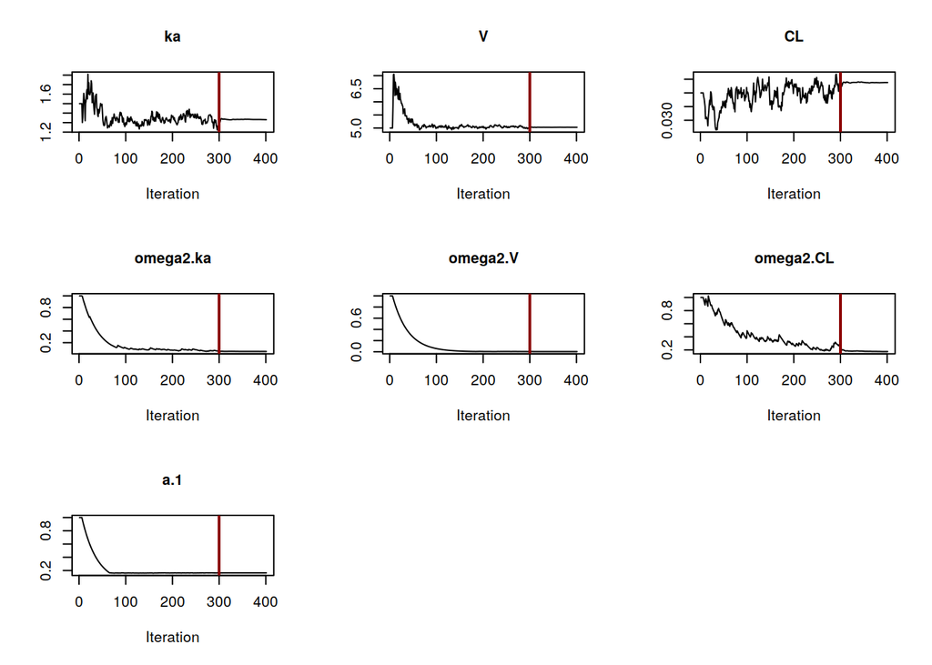

```
## Plotting convergence plots
```

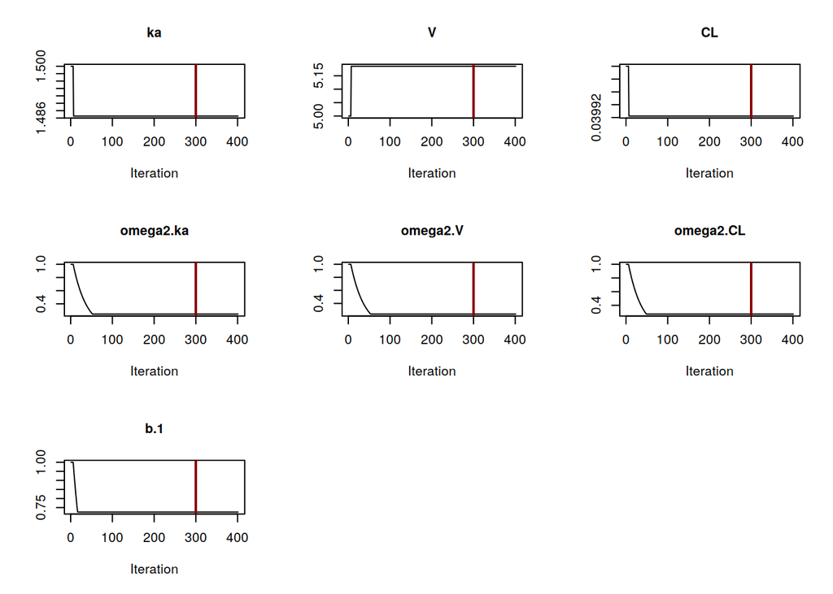

```r
plot(fit2,plot.type="convergence")
```

## Estimation with Monolix

- Model ka, V, Cl

Population parameter estimates VALUE STOCH. APPROX. S.E. R.S.E.(%) Fixed Effects ka_pop 2.87e+64 1.79e+67 6.23e+4 V_pop 2.58e-171 nan nan Cl_pop 1 nan nan Standard Deviation of the Random Effects omega_ka 338 179 53 omega_V 204 27 13.3 omega_Cl 3.6e+56 nan nan Error Model Parameters b 0.3 nan nan

- Model ka, V, Cl, Tlag

Population parameter estimates VALUE STOCH. APPROX. S.E. R.S.E.(%) Fixed Effects Tlag_pop 1 nan nan ka_pop 1.08e+62 2.1e+65 1.94e+5 V_pop 1.34e-171 nan nan Cl_pop 1 nan nan Standard Deviation of the Random Effects omega_Tlag 5.31e+57 nan nan omega_ka 346 538 155 omega_V 207 37.7 18.3 omega_Cl 1.63e+58 nan nan Error Model Parameters b 0.3 nan nan

# Problem with the error model, debugging step by step

Initialisation of the algorithm:

```r
saemix.model2<-saemixModel(model=model1cpt,description="One compartment model", modeltype="structural", psi0=matrix(c(psi1,0,0,0),ncol=3,byrow=TRUE, dimnames=list(NULL, c("ka","V","CL"))), transform.par=c(1,1,1),  covariance.model=diag(3), error.model="proportional")
```

```
##
##
## The following SaemixModel object was successfully created:
##
## Nonlinear mixed-effects model
##   Model function:  One compartment model  Model type:  structural
## function(psi,id,xidep) {
##   tim<-xidep[,1]
##   dose<-xidep[,2]
##   ka<-psi[id,1]
##   V<-psi[id,2]
##   CL<-psi[id,3]
##   k<-CL/V
##   ypred<-dose*ka/(V*(ka-k))*(exp(-k*tim)-exp(-ka*tim))
##   return(ypred)
## }
## <bytecode: 0x563370d5e4d0>
##   Nb of parameters: 3
##       parameter names:  ka V CL
##       distribution:
##      Parameter Distribution Estimated
## [1,] ka        log-normal   Estimated
## [2,] V         log-normal   Estimated
## [3,] CL        log-normal   Estimated
##   Variance-covariance matrix:
##    ka V CL
## ka  1 0  0
## V   0 1  0
## CL  0 0  1
##   Error model: proportional , initial values: b.1=1
##     No covariate in the model.
##     Initial values
##               ka V   CL
## Pop.CondInit 1.5 5 0.04
## Cov.CondInit 0.0 0 0.00
```

```r
saemix.options<-list(nb.chains=3,seed=123456,save=FALSE, save.graphs=FALSE)
saemix.data<-saemixData(name.data=simdat,header=TRUE,sep="",na=NA, name.group=c("id"), name.predictors=c("time","dose"),name.response=c("conc"))
```

```
## Using the object called simdat in this R session as the data.
##
##
## The following SaemixData object was successfully created:
##
## Object of class SaemixData
##     longitudinal data for use with the SAEM algorithm
## Dataset simdat
##     Structured data: conc ~ time + dose | id
##     X variable for graphs: time ()
```

```r
  saemixObject<-new(Class="SaemixObject",data=saemix.data,model=saemix.model2,options=saemix.options)
  opt.warn<-getOption("warn")
  if(!saemixObject["options"]$warnings) options(warn=-1)

  saemix.options<-saemixObject["options"]
  saemix.model<-saemixObject["model"]
  saemix.data<-saemixObject["data"]
  saemix.data@ocov<-saemix.data@ocov[saemix.data@data[,"mdv"]==0,,drop=FALSE]
  saemix.data@data<-saemix.data@data[saemix.data@data[,"mdv"]==0,]
  saemix.data@ntot.obs<-dim(saemix.data@data)[1]

# Initialisation
  OLDRAND<-TRUE
  set.seed(saemix.options$seed)
  xinit<-initialiseMainAlgo(saemix.data,saemix.model,saemix.options)
  saemix.model<-xinit$saemix.model
  Dargs<-xinit$Dargs
  Uargs<-xinit$Uargs
  varList<-xinit$varList
  phiM<-xinit$phiM
  mean.phi<-xinit$mean.phi
  DYF<-xinit$DYF
  opt<-xinit$opt
  betas<-betas.ini<-xinit$betas
  fixed.psi<-xinit$fixedpsi.ini
  var.eta<-varList$diag.omega

  if (Dargs$modeltype=="structural"){
    theta0<-c(fixed.psi,var.eta[Uargs$i1.omega2],varList$pres[Uargs$ind.res])
    parpop<-matrix(data=0,nrow=(saemix.options$nbiter.tot+1),ncol=(Uargs$nb.parameters+length(Uargs$i1.omega2)+length(saemix.model["indx.res"])))
    colnames(parpop)<-c(saemix.model["name.modpar"], saemix.model["name.random"], saemix.model["name.sigma"][saemix.model["indx.res"]])
    allpar<-matrix(data=0,nrow=(saemix.options$nbiter.tot+1), ncol=(Uargs$nb.betas+length(Uargs$i1.omega2)+length(saemix.model["indx.res"])))
    colnames(allpar)<-c(saemix.model["name.fixed"],saemix.model["name.random"], saemix.model["name.sigma"][saemix.model["indx.res"]])
  } else{
    theta0<-c(fixed.psi,var.eta[Uargs$i1.omega2])
    parpop<-matrix(data=0,nrow=(saemix.options$nbiter.tot+1),ncol=(Uargs$nb.parameters+length(Uargs$i1.omega2)))
    colnames(parpop)<-c(saemix.model["name.modpar"], saemix.model["name.random"])
    allpar<-matrix(data=0,nrow=(saemix.options$nbiter.tot+1), ncol=(Uargs$nb.betas+length(Uargs$i1.omega2)))
    colnames(allpar)<-c(saemix.model["name.fixed"],saemix.model["name.random"])
  }

  parpop[1,]<-theta0
  allpar[1,]<-xinit$allpar0

  # using several Markov chains - only useful if passed back to main routine...
  #     chdat<-new(Class="SaemixRepData",data=saemix.data, nb.chains=saemix.options$nb.chains)
  #     NM<-chdat["NM"]
  #     IdM<-chdat["dataM"]$IdM
  #     yM<-chdat["dataM"]$yM
  #     XM<-chdat["dataM"][,saemix.data["name.predictors"],drop=FALSE]

# List of sufficient statistics - change during call to stochasticApprox
  suffStat<-list(statphi1=0,statphi2=0,statphi3=0,statrese=0)
  phi<-array(data=0,dim=c(Dargs$N, Uargs$nb.parameters, saemix.options$nb.chains))

# structural model, check nb of parameters
  structural.model<-saemix.model["model"]
  #  nb.parameters<-saemix.model["nb.parameters"]
```

Burn-in iterations:

```r
for (kiter in 1:saemix.options$nbiter.burn) { # Iterative portion of algorithm
# Burn-in - first loop useless
# E-step
  xmcmc<-estep(kiter, Uargs, Dargs, opt, structural.model, mean.phi, varList, DYF, phiM)
  varList<-xmcmc$varList
  DYF<-xmcmc$DYF
  phiM<-xmcmc$phiM

  # no M-step during burn-in phase
  allpar[(kiter+1),]<-allpar[kiter,]
  if(Dargs$modeltype=="structural") {
    theta<-c(fixed.psi,var.eta[Uargs$i1.omega2],varList$pres[Uargs$ind.res])
  } else{
    theta<-c(fixed.psi,var.eta[Uargs$i1.omega2])
  }
  parpop[(kiter+1),]<-theta
}
print(theta)
```

```
##   ka    V   CL   ka    V   CL
## 1.50 5.00 0.04 1.00 1.00 1.00 1.00
```

```r
print(head(phiM))
```

```
##           [,1]     [,2]      [,3]
## [1,] 0.8223317 1.738545 -2.643260
## [2,] 0.2674412 2.091693 -2.881193
## [3,] 0.2279642 1.363799 -2.611791
## [4,] 0.4492088 1.650257 -3.580531
## [5,] 1.5315930 1.528553 -3.719117
## [6,] 0.8226952 2.245846 -3.280672
```

```r
print(varList$pres)
```

```
## [1] 0 1
```

Something goes wrong in xstoch:

- sum(Dargs$yobs-fk)**2/cutoff(fk**2,.Machine$double.eps) explodes when predictions are very small (fk=0 or smaller than machine precision)
- changed code below to ignore the terms for which fk is too small in the summation

```r
kiter<-saemix.options$nbiter.burn+1
    # E-step
  xmcmc<-estep(kiter, Uargs, Dargs, opt, structural.model, mean.phi, varList, DYF, phiM)
  varList<-xmcmc$varList
  DYF<-xmcmc$DYF
  phiM<-xmcmc$phiM

  # M-step and stochastic Approximation

#  xstoch<-mstep(kiter, Uargs, Dargs, opt, structural.model, DYF, phiM, varList, phi, betas, suffStat)

    # Update variances - TODO - check if here or elsewhere
    nb.etas<-length(varList$ind.eta)
    domega<-cutoff(mydiag(varList$omega[varList$ind.eta,varList$ind.eta]),.Machine$double.eps)
    omega.eta<-varList$omega[varList$ind.eta,varList$ind.eta,drop=FALSE]
    omega.eta<-omega.eta-mydiag(mydiag(varList$omega[varList$ind.eta,varList$ind.eta]))+mydiag(domega)
    #  print(varList$omega.eta)
    chol.omega<-try(chol(omega.eta))
    d1.omega<-Uargs$LCOV[,varList$ind.eta]%*%solve(omega.eta)
    d2.omega<-d1.omega%*%t(Uargs$LCOV[,varList$ind.eta])
    comega<-Uargs$COV2*d2.omega

    psiM<-transphi(phiM,Dargs$transform.par)
    fpred<-structural.model(psiM, Dargs$IdM, Dargs$XM)
    for(ityp in Dargs$etype.exp) fpred[Dargs$XM$ytype==ityp]<-log(cutoff(fpred[Dargs$XM$ytype==ityp]))
#   if(Dargs$error.model=="exponential")
#       fpred<-log(cutoff(fpred))
    ff<-matrix(fpred,nrow=Dargs$nobs,ncol=Uargs$nchains)
    for(k in 1:Uargs$nchains) phi[,,k]<-phiM[((k-1)*Dargs$N+1):(k*Dargs$N),]
    # overall speed similar
    #    phi<-aperm(array(phiM,c(N,nchains,3)),c(1,3,2))
    stat1<-apply(phi[,varList$ind.eta,,drop=FALSE],c(1,2),sum) # sum on columns ind.eta of phi, across 3rd dimension
    stat2<-matrix(data=0,nrow=nb.etas,ncol=nb.etas)
    stat3<-apply(phi**2,c(1,2),sum) #  sum on phi**2, across 3rd dimension
    statr<-0
    for(k in 1:Uargs$nchains) {
        phik<-phi[,varList$ind.eta,k]
        stat2<-stat2+t(phik)%*%phik
        fk<-ff[,k]
        if(length(Dargs$error.model)==1) {
          if(!is.na(match(Dargs$error.model,c("constant","exponential"))))
            resk<-sum((Dargs$yobs-fk)**2) else {
              if(Dargs$error.model=="proportional") {
                idx.okpred<-which(fk>.Machine$double.eps)
                vec<-(Dargs$yobs-fk)**2/cutoff(fk**2,.Machine$double.eps)
                resk<-sum(vec[idx.okpred])
                resk1<-sum(vec)
                } else resk<-0
            }
        } else resk<-0
        statr<-statr+resk
    }

print(resk)
```

```
## [1] 421.1211
```

```r
print(resk1)
```

```
## [1] 1.958607e+15
```

```r
kiter<-saemix.options$nbiter.burn+1
    # E-step
  xmcmc<-estep(kiter, Uargs, Dargs, opt, structural.model, mean.phi, varList, DYF, phiM)
  varList<-xmcmc$varList
  DYF<-xmcmc$DYF
  phiM<-xmcmc$phiM
  #  psiM<-transphi(phiM,saemix.model["transform.par"])

  #

  # M-step
#  if(opt$stepsize[kiter]>0) {
############# Stochastic Approximation
    xstoch<-mstep(kiter, Uargs, Dargs, opt, structural.model, DYF, phiM, varList, phi, betas, suffStat)
    varList<-xstoch$varList
    mean.phi<-xstoch$mean.phi
    phi<-xstoch$phi
    betas<-xstoch$betas
    suffStat<-xstoch$suffStat

    beta.I<-betas[Uargs$indx.betaI]
    fixed.psi<-transphi(matrix(beta.I,nrow=1),saemix.model["transform.par"])
    betaC<-betas[Uargs$indx.betaC]
    var.eta<-mydiag(varList$omega)
    l1<-betas.ini
    l1[Uargs$indx.betaI]<-fixed.psi
    l1[Uargs$indx.betaC]<-betaC

    if(Dargs$modeltype=="structural") {
      allpar[(kiter+1),]<-c(l1,var.eta[Uargs$i1.omega2],varList$pres[Uargs$ind.res])
    } else{
      allpar[(kiter+1),]<-c(l1,var.eta[Uargs$i1.omega2])
    }

  # } else { #end of loop on if (stepsize[kiter]>0)
  #   allpar[(kiter+1),]<-allpar[kiter,]
  # }
   if(Dargs$modeltype=="structural") {
      theta<-c(fixed.psi,var.eta[Uargs$i1.omega2],varList$pres[Uargs$ind.res])
    } else{
      theta<-c(fixed.psi,var.eta[Uargs$i1.omega2])
    }
  parpop[(kiter+1),]<-theta

print(theta)
print(head(phiM))
print(varList$pres)
```

[output not shown]

```r
saemixObject<-fit2b
```

```r
kiter<-saemix.options$nbiter.burn+1

for (kiter in (saemix.options$nbiter.burn+1):(saemix.options$nbiter.sa)) { #
# Burn-in - resetting sufficient statistics
  if(opt$flag.fmin && kiter==saemix.options$nbiter.sa) {
    cat("Inside first loop, kiter=",kiter,":\n")
    Uargs$COV1<-Uargs$COV[,Uargs$ind.fix11]
    ind.prov<-!(varList$ind.eta %in% Uargs$i0.omega2)
    varList$domega2<-varList$domega2[ind.prov,ind.prov,drop=FALSE] # keep in domega2 only indices of parameters with IIV
    varList$ind0.eta<-Uargs$i0.omega2
    varList$ind.eta<-1:(Uargs$nb.parameters)
    if(length(varList$ind0.eta)>0) varList$ind.eta<-varList$ind.eta[!(varList$ind.eta %in% varList$ind0.eta)] # update ind.eta, now only parameters with IIV
    Uargs$nb.etas<-length(varList$ind.eta)
    suffStat$statphi1<-0
    suffStat$statphi2<-0
    suffStat$statphi3<-0
  }

    # E-step
  xmcmc<-estep(kiter, Uargs, Dargs, opt, structural.model, mean.phi, varList, DYF, phiM)
  varList<-xmcmc$varList
  DYF<-xmcmc$DYF
  phiM<-xmcmc$phiM
  #  psiM<-transphi(phiM,saemix.model["transform.par"])

  # M-step
  if(opt$stepsize[kiter]>0) {
############# Stochastic Approximation
    xstoch<-mstep(kiter, Uargs, Dargs, opt, structural.model, DYF, phiM, varList, phi, betas, suffStat)
    varList<-xstoch$varList
    mean.phi<-xstoch$mean.phi
    phi<-xstoch$phi
    betas<-xstoch$betas
    suffStat<-xstoch$suffStat

    beta.I<-betas[Uargs$indx.betaI]
    fixed.psi<-transphi(matrix(beta.I,nrow=1),saemix.model["transform.par"])
    betaC<-betas[Uargs$indx.betaC]
    var.eta<-mydiag(varList$omega)
    l1<-betas.ini
    l1[Uargs$indx.betaI]<-fixed.psi
    l1[Uargs$indx.betaC]<-betaC

    if(Dargs$modeltype=="structural") {
      allpar[(kiter+1),]<-c(l1,var.eta[Uargs$i1.omega2],varList$pres[Uargs$ind.res])
    } else{
      allpar[(kiter+1),]<-c(l1,var.eta[Uargs$i1.omega2])
    }

  } else { #end of loop on if (stepsize[kiter]>0)
    allpar[(kiter+1),]<-allpar[kiter,]
  }
   if(Dargs$modeltype=="structural") {
      theta<-c(fixed.psi,var.eta[Uargs$i1.omega2],varList$pres[Uargs$ind.res])
    } else{
      theta<-c(fixed.psi,var.eta[Uargs$i1.omega2])
    }
  parpop[(kiter+1),]<-theta

# End of loop on kiter
}
print(theta)
print(head(phiM))
print(varList$pres)
```

[output not shown]